# BDgraph with Simple Examples

Reza Mohammadi (https://orcid.org/0000-0001-9538-0648)

2023-11-14

The `R` package **BDgraph** provides statistical tools for Bayesian structure learning for undirected graphical models with *continuous*, *count*, *binary*, and *mixed data*. The package is implemented the recent improvements in the Bayesian graphical models’ literature, including [Mohammadi and Wit (2015)](https://projecteuclid.org/euclid.ba/1422468425), [Mohammadi et al. (2021)](https://doi.org/10.1080/01621459.2021.1996377), [Mohammadi et al. (2017)](https://doi.org/10.1111/rssc.12171), and [Dobra and Mohammadi (2018)](https://projecteuclid.org/euclid.aoas/1532743478). Besides, the package contains several functions for simulation and visualization, as well as several multivariate datasets taken from the literature.

Install **BDgraph** using

```r
install.packages( "BDgraph" )
```

First, we load **BDgraph** package

```r
library( BDgraph )
```

Here are two simple examples to show how to use the functionality of the package.

# Example 1: Gaussian Graphical Models

Here is a simple example to see the performance of the package for the Gaussian graphical models. First, by using the function `bdgraph.sim()`, we simulate 200 observations (n = 200) from a multivariate Gaussian distribution with 15 variables (p = 15) and “scale-free” graph structure, as follows

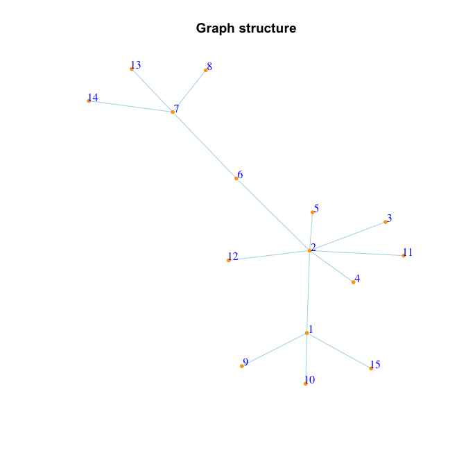

```r
set.seed( 20 )

data.sim = bdgraph.sim( n = 200, p = 15, graph = "scale-free", vis = TRUE )
```

Since the generated data are Gaussian, we run the `bdgraph()` function by choosing `method = "ggm"`, as follows

```r
bdgraph.obj = bdgraph( data = data.sim, method = "ggm", iter = 5000, verbose = FALSE )
```

To report confusion matrix with cutoff point 0.5:

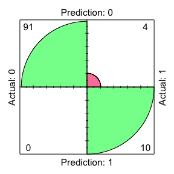

```r
conf.mat( actual = data.sim, pred = bdgraph.obj, cutoff = 0.5 )
            Actual
  Prediction  0  1
           0 91  4
           1  0 10

conf.mat.plot( actual = data.sim, pred = bdgraph.obj, cutoff = 0.5 )
```

To compare the result with the true graph

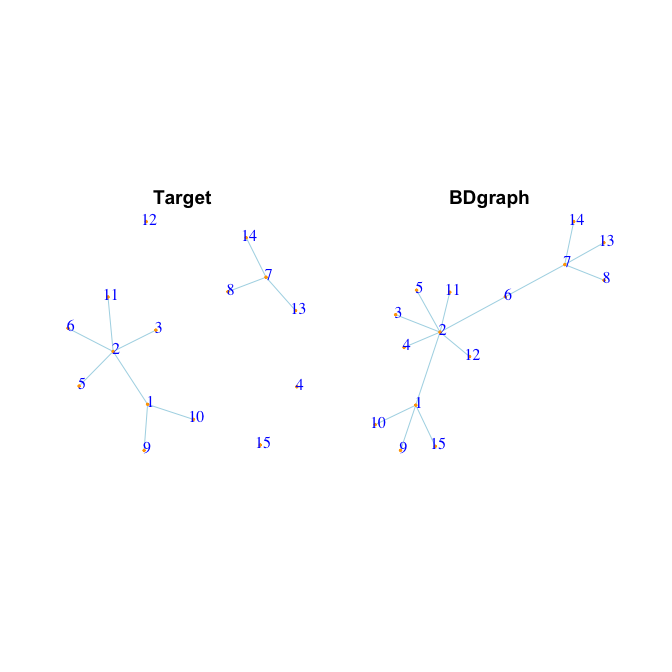

```
                 Target BDgraph
  True Positive      10  10.000
  True Negative      95  91.000
  False Positive      0   4.000
  False Negative      0   0.000
  F1-score            1   0.833
  Specificity         1   0.958
  Sensitivity         1   1.000
  MCC                 1   0.827
```

```r
compare( data.sim, bdgraph.obj, main = c( "Target", "BDgraph" ), vis = TRUE )
```

Now, as an alternative, we run the `bdgraph.mpl()` function which is based on the GGMs and marginal pseudo-likelihood, as follows

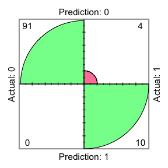

```r
bdgraph.mpl.obj = bdgraph.mpl( data = data.sim, method = "ggm", iter = 5000, verbose = FALSE )

conf.mat( actual = data.sim, pred = bdgraph.mpl.obj )
            Actual
  Prediction  0  1
           0 91  4
           1  0 10
conf.mat.plot( actual = data.sim, pred = bdgraph.mpl.obj )
```

We could compare the results of both algorithms with the true graph as follows

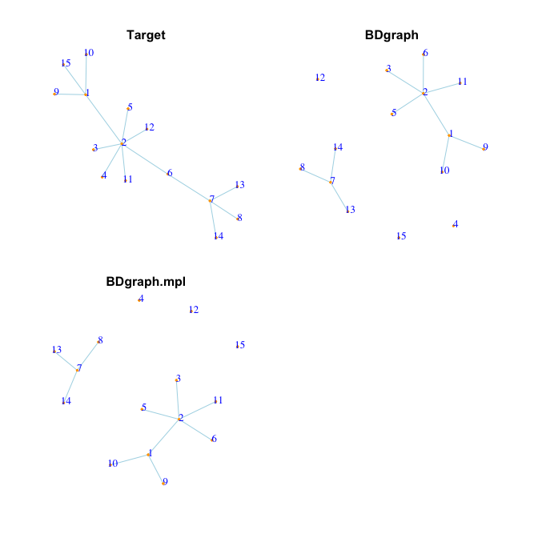

```
                 Target BDgraph BDgraph.mpl
  True Positive      14  10.000      10.000
  True Negative      91  91.000      91.000
  False Positive      0   0.000       0.000
  False Negative      0   4.000       4.000
  F1-score            1   0.833       0.833
  Specificity         1   1.000       1.000
  Sensitivity         1   0.714       0.714
  MCC                 1   0.827       0.827
```

```r
compare( list( bdgraph.obj, bdgraph.mpl.obj ), data.sim,
         main = c( "Target", "BDgraph", "BDgraph.mpl" ), vis = TRUE )
```

To see the performance of the BDMCMC algorithm we could plot the ROC curve as follows

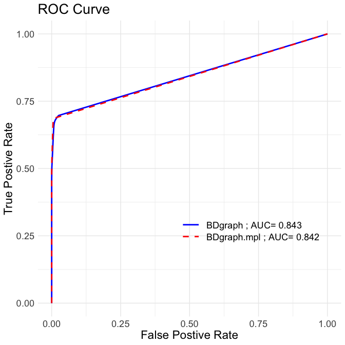

```r
plotroc( list( bdgraph.obj, bdgraph.mpl.obj ), data.sim, cut = 200,
         labels = c( "BDgraph", "BDgraph.mpl" ), color = c( "blue", "red" ) )
```

# Example 2: Gaussian Copula Graphical Models

Here is a simple example to see the performance of the package for the mixed data using Gaussian copula graphical models. First, by using the function `bdgraph.sim()`, we simulate 300 observations (n = 300) from mixed data (`type = "mixed"`) with 10 variables (p = 10) and “random” graph structure, as follows

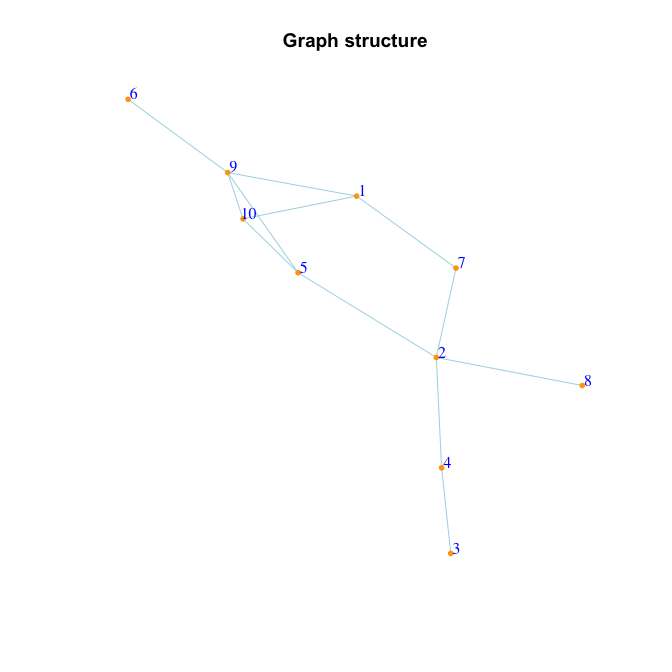

```r
set.seed( 2 )

data.sim = bdgraph.sim( n = 300, p = 10, type = "mixed", graph = "random", vis = TRUE )
```

Since the generated data are mixed data, we are using run the `bdgraph()` function by choosing `method = "gcgm"`, as follows:

```r
bdgraph.obj = bdgraph( data = data.sim, method = "gcgm", iter = 5000, verbose = FALSE )
```

To compare the result with the true graph, we could run

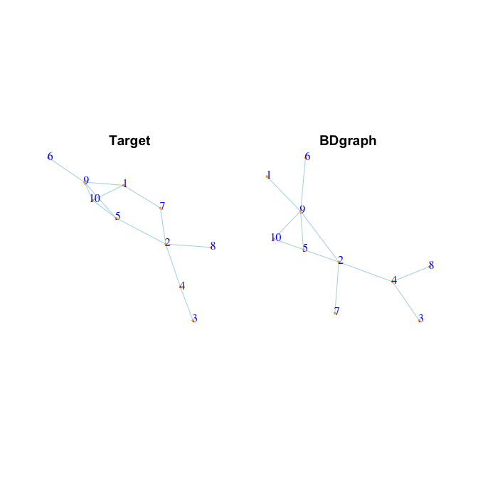

```
                 Target BDgraph
  True Positive      12   9.000
  True Negative      33  31.000
  False Positive      0   2.000
  False Negative      0   3.000
  F1-score            1   0.783
  Specificity         1   0.939
  Sensitivity         1   0.750
  MCC                 1   0.709
```

```r
compare( bdgraph.obj, data.sim, main = c( "Target", "BDgraph" ), vis = TRUE )
```

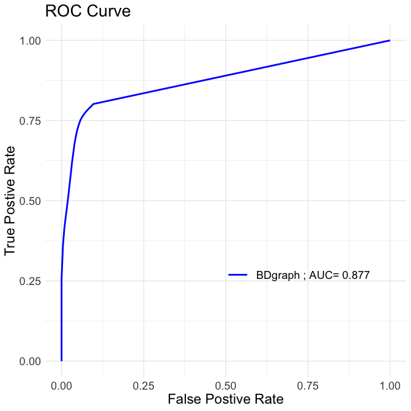

```r
plotroc( bdgraph.obj, data.sim, labels = "BDgraph", color = "blue" )
```

For more examples see [Mohammadi and Wit (2019)](https://www.jstatsoft.org/article/view/v089i03).